# fun with word vectors

feb28/2018

## What are "word vectors"?

- an *embedding* for a word \(w\) is a short sequence of numbers representing "the meaning" of \(w\) – or more accurately: "the distribution" of \(w\) in a training corpus."
- with a sufficiently large corpus (millions of words), intuitive relationships between words are reflected directly in the numerical representations.

### **in short**

- word vectors are a way to represent the meaning of a word using a sequence of numbers.
- their content reflects the contexts in which the underlying words are used in a corpus.

*ambiguous, but usually refers to *word embeddings*

## What are they good for?!

famously, certain analogies can be derived:

```r
closest_word_vec(wv("king"), exclude=c("king","kings","kingdoms"))
```

```
##     queen
## 0.6510958
```

```r
closest_word_vec(wv("queen"), exclude=c("queen","queens","queendom"))
```

```
##  princess
## 0.7070532
```

```r
closest_word_vec(
  vec = wv("king") - wv("man") + wv("woman"),
  exclude = c("king","kings","man","men","woman","women"))
```

```
##     queen
## 0.7118194
```

## What are they good for?!

similarity between sequences of numbers can be measured with euclidean distance/cosine similarity.

```r
# for vectors A,B of length n:
#   >> take the sum from 1 to n of Ai*Bi over
#      the product of the respective root sum of squares
euc_dist <- function(v1, v2){
  sum(v1*v2) /
    ((sqrt(sum(v1^2))) * (sqrt(sum(v2^2))))
}
```

## What are they good for?!

if words are just sequences of numbers, then we estimate word similarity in exactly this fashion!

```r
euc_dist(wv("queen"), wv("king") - wv("man") + wv("woman"))
```

```
## [1] 0.7118194
```

```r
euc_dist(wv("prince"), wv("princess") - wv("girl") + wv("boy"))
```

```
## [1] 0.7020795
```

## What are they good for?!

you can also **discover** words that are similar to one you have in mind:

```r
# notice anything about the similar words??
closest_n_words(word="dog", n=5, vec_grid=vec_dists)
```

| word | close_word | distance |
| --- | --- | --- |
| dog | animal | 0.6438014 |
| dog | child | 0.3700999 |
| dog | someone | 0.3617023 |
| dog | baby | 0.3560090 |
| dog | boy | 0.3521682 |

## What are they good for?!

you can also **discover** words that are similar to one you have in mind:

```r
closest_n_words(word="talk", n=5, vec_grid=vec_dists)
```

[output not shown]

## Visualizing words in vector space (and in 2-d space)

#### visualize word meanings with a heatmap

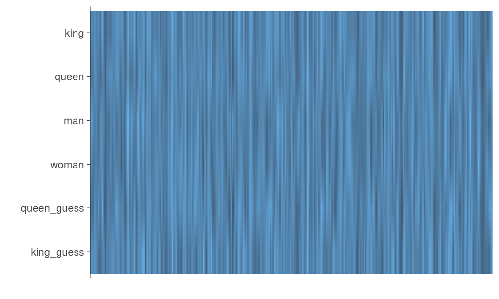

## Visualizing words in vector space (and in 2-d space)

#### visualize word meanings with a heatmap

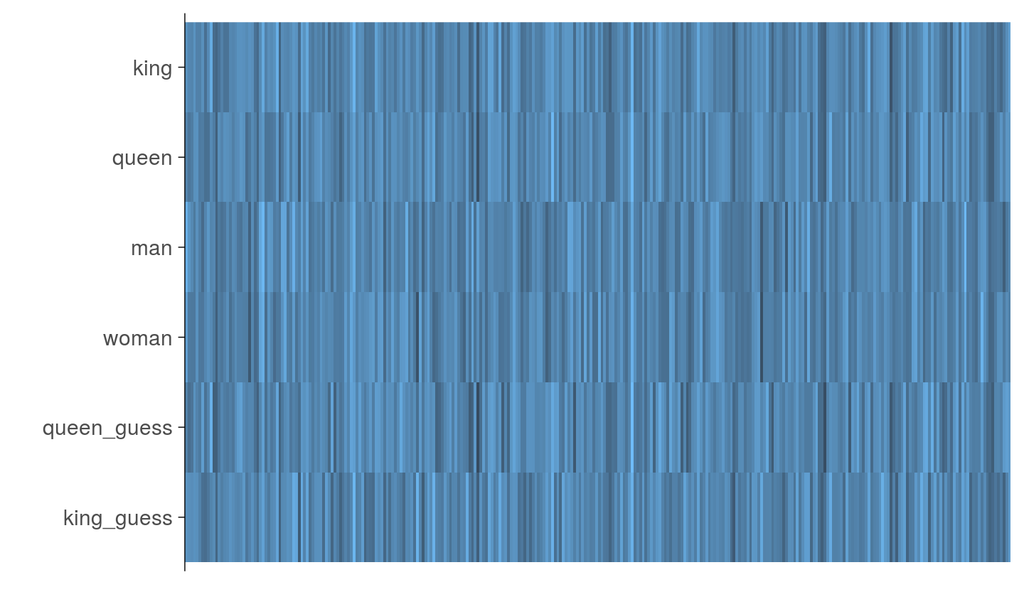

## Visualizing words in vector space (and in 2-d space)

#### visualize word meanings in 2-d space (some info is lost)

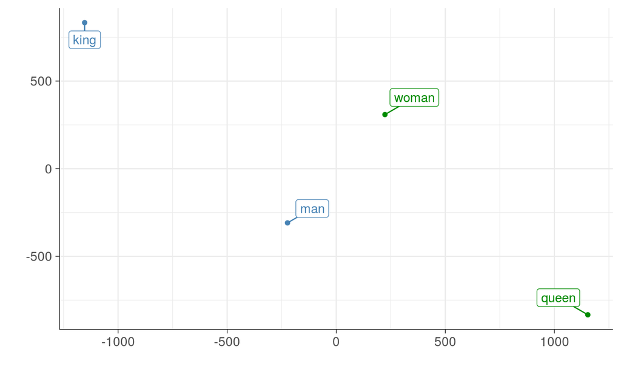

*this plot was created using a dimensionality reduction technique called "t-distributed stochastic neighbor embedding" (T-SNE)

## Where do they come from?!

- an embedding for a word \(w\) is a short (\(n\approx \{25,\ldots,200\}\)) sequence of real numbers that represents the meaning or distribution of \(w\)
- embeddings are derived by factorization of a very large term-term cooccurrence matrix
- the resulting low dimensional matrix holds the "word vectors" – e.g. with a 1000 word vocabulary, we would have a 1000x100 matrix containing a row for each word
- basically, you do some dimensionality reduction magic to reduce the huge matrix into a more manageable one (some info necessarily lost)

## Most common models

the most common frameworks for training word embeddings:

- **word2vec** – came from Google, see [[this seminal paper](https://papers.nips.cc/paper/5021-distributed-representations-of-words-and-phrases-and-their-compositionality.pdf)] (Mikolov et al. 2013)
- **GloVe** – came from Stanford, see [[paper](https://nlp.stanford.edu/pubs/glove.pdf)] and [[homepage](https://nlp.stanford.edu/projects/glove/)] (Pennington, Socher, and Manning 2014)

## Most common models

common techniques for constructing input matrices are:

- **CBOW** (continuous bag of words); and
- **skip-gram** (used in word2vec)

both involve counting co-occurrences of every pair of words in the vocab, across a moving window of fixed size

> The GloVe model is trained on the non-zero entries of a global word-word co-occurrence matrix, which tabulates how frequently words co-occur with one another in a given corpus. Populating this matrix requires a single pass through the entire corpus to collect the statistics. For large corpora, this pass can be computationally expensive, but it is a one-time up-front cost. Subsequent training iterations are much faster because the number of non-zero matrix entries is typically much smaller than the total number of words in the corpus.

## Some cool tricks

- find words most similar to a given word (**got a word in mind, anyone??**)
- visualize the similarity of a set of words (**got a set of words in mind, anyone??**)
- combine vectors to "construct a word-meaning", and then see what *that* is similar to (**got a word-based analogy in mind, anyone??**)

## Cigarettes example

```r
closest_word_vec(wv('cigarette'), exclude=cig_words)
```

```
##     cigar
## 0.6175426
```

```r
closest_word_vec(wv('cigarette') - wv('tobacco'), exclude=cig_words)
```

```
##  bathrobe
## 0.2970107
```

```r
closest_word_vec(wv('cigarette') - wv('tobacco') + wv('marijuana'),
                 exclude=cig_words)
```

```
## marijuana
##  0.772469
```

## Cigarettes example

#### hypothesis: if we used twitter-trained embeddings, then we could derive the following:

> `wv('cigar') - wv('tobacco') + wv('weed')`\(\approx\)`wv(blunt)`

```r
# but nothing much here :(
euc_dist(wv('cigarette')-wv('tobacco')+wv('marijuana'), wv('joint'))
```

```
## [1] 0.09615474
```

```r
euc_dist(wv('cigar')-wv('tobacco')+wv('marijuana'), wv('blunt'))
```

```
## [1] 0.07518813
```

## Dogs/cats example

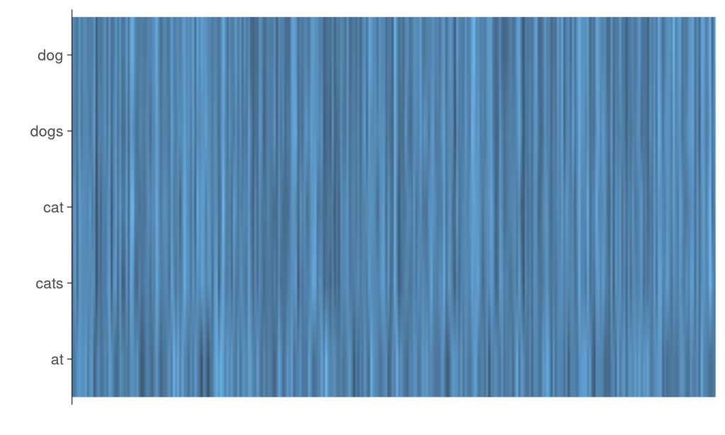

## Dogs/cats example

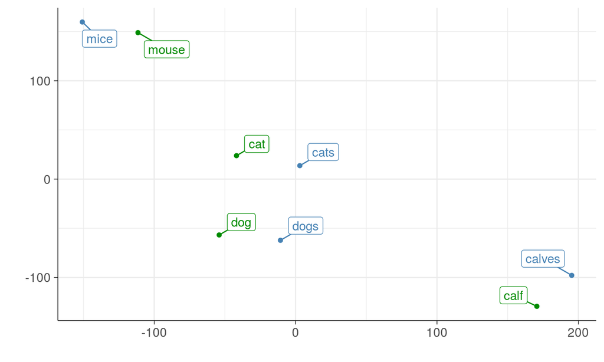

## Regular/irregular morphology example

```r
str(words_df)
```

```
## Classes 'tbl_df', 'tbl' and 'data.frame':    40 obs. of  3 variables:
##  $ word   : chr  "want" "look" "use" "work" ...
##  $ regular: logi  TRUE TRUE TRUE TRUE TRUE TRUE ...
##  $ feature: chr  "tense_prs" "tense_prs" "tense_prs" "tense_prs" ...
```

## Regular/irregular morphology example (verbs against nouns)

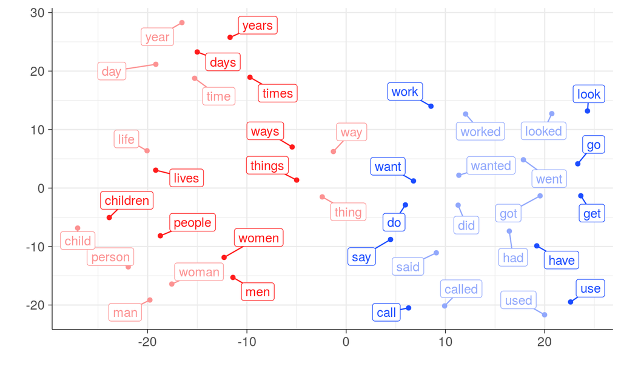

## Regular/irregular morphology example (closer look at verbs)

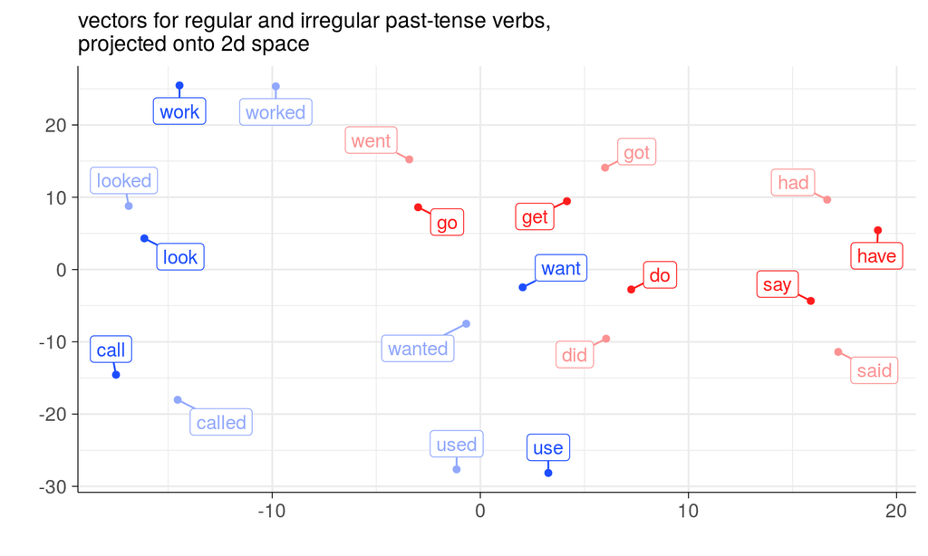

## Some project ideas

- learn semantic composition by training 1-, 2-, …, -gram vectors
- a visual tool for keyword discovery and similarity measurement
- train vecs on different subsets + compare (e.g. by time, as in post from last wk)
- …